# Shiny Uygulamalarına Giriş

R ile Program Yazmanın En Kolay Hali

Onlarca satır yazıp tablolar ve grafikler oluşturdunuz. Elinizdeki sonuçları başkaları ile paylaşmak istiyorsunuz. Ancak, paylaşmak istediğiniz insanlar bu R kodlarını nasıl kullanacağını veya parametreleri nasıl değiştirebileceğini bilmiyor. Tam da bu noktada, [Shiny](http://shiny.rstudio.com/) adını verdiğimiz web uygulamaları yardımınıza yetişiyor.

Shiny, kullanıcı dostu arayüzlere sahip arayüzler tasarlamanıza olanak veren bir R paketi. Ve bu paket ile kullanıcıların kolaylıkla parametreleri değiştirip grafikler, tablolar veya analiz sonuçları oluşturabileceği web uygulamaları hazırlayabiliyorsunuz.

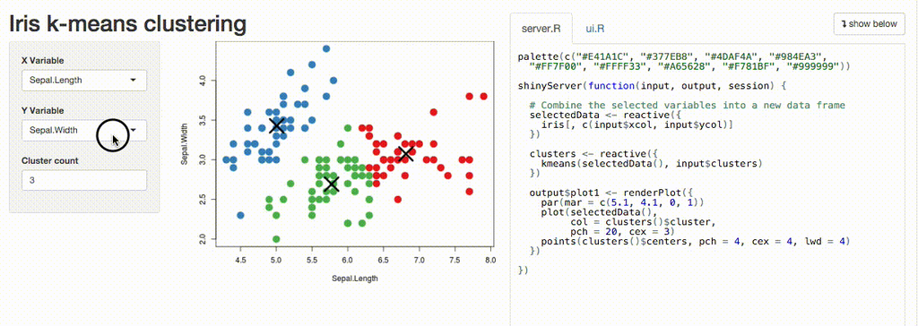

Shiny ile kod üzerinde değişiklik yapmadan; sadece belirlediğiniz butonlara basarak parametreleri değiştirebileceğiniz ve otomatik olarak görsellerin veya tabloların oluşturabileceği web uygulamalarını kolayca yazmak mümkün. Konu oldukça derin olduğu için öncelikle temelden başlayacağız.

# Proje Oluşturma

Her ne kadar **RStudio** ile birlikte gelse de, Shiny uygulamaları tasarlamak için Shiny paketine ihtiyacımız var. Bunun için öncelikle paketimizi yükleyelim.

```r
install.packages("shiny")
```

Paketi kurduktan sonra, **File / New File / Shiny Web App..** yolu ile ilk projemizi oluşturalım. Bu süreçte çıkan pencerede uygulamanıza koyacağınız adı belirleyebilirsiniz.

[figure not shown]

Bir sonraki basamakta web uygulamanızın dosya tipine karar vermeniz gerekiyor. **Application Type** seçeneğinde Shiny, kullanıcıların göreceği arayüzü (*ui.R dosyası*) ve arkaplanda çalışacak algoritmaları barındıran dosyayı (*server.R dosyası*) ayrı ayrı tutmak isteyip istemediğinizi soruyor. Ayrı tutmak isterseniz **Multiple File** seçeneğini seçebilirsiniz. Alternatif olarak bu iki dosyayı aynı dosya içinden de yönetmek isterseniz **Single File** (*app.R*) seçeneğini seçebilirsiniz. Kişisel olarak küçük uygulamalarda tek dosya üzerinde çalışmayı daha rahat buluyorum. **Create** dediğinizde ilk uygulamanızı oluşturacaktır.

**Not:** Dosya isimlerini olduğu gibi bırakın. Dosya isimleri varsayılan değerlerdir. Adlarını değiştirmeniz programınızın çalışmayacaktır.

# Temiz Başlangıç

Sayfa açıldığında, demo bir Shiny uygulaması otomatik olarak karşınıza gelecektir. Şimdilik kod içeriğini göz ardı edin ve sayfanın sağ üst tarafında yer alan ► **Run App** butonuna basın.

Yeni bir pencere içinde ilk Shiny uygulamanızı çalıştırmış olacaksınız. Çubuğu kaydırarak yeni grafiğin oluşturulmasını test edebilirsiniz. Basit ama harika değil mi?

Şimdi kendi arayüzümüzü tasarlamaya başlayalım. Demo ile birlikte gelen kodlar ilk başta biraz karmaşık gelebilir. O yüzden onu tamamen silin. Onun yerine, her zaman kullanabileceğiniz temiz bir şablonu paylaşıyorum. İster ilk uygulamanız olsun, ister 1000. uygulamanız olsun, her defasında bu şablonu kullanabilirsiniz.

```r
library(shiny)

ui <- fluidPage() # kullanıcıların göreceği arayüzdeki her şey burada yere alacak.

server <- function(input, output) {} # arayüzde görülen tüm nesneler burada tanımlanacak.

shinyApp(ui = ui, server = server)
```

Shiny uygulamalarının her zaman iki tarafı var. Bunun birisi arayüzde göreceğiniz tüm nesneleri göreceğiniz **user interface** (ui) denilen kullanıcı arayüzü ve arayüzde göstereceğiniz bu nesnelere (grafik, tablo vs) ait hesaplamaların ve tanımlamaların yapılacağı **server** adı verilen kısım.

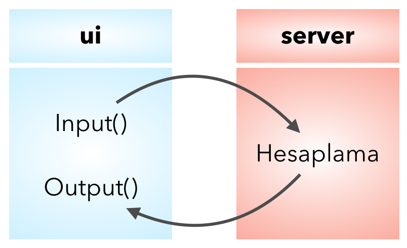

Kullanıcı arayüzünde yer alan öğeleri `ui <- fluidPage()` ifadesi içine yazıyoruz. Bu öğeler, kullanıcı tarafından girilecek değerler (**input**) veya kullanıcıya gösterilecek (**output**) bir grafik olabilir.

Kullanıcı tarafından girilebilecek değerler, yazı, sayı, tarih veya bir dosya olabilir. Shiny, her bir tip input için size hazır widget’lar sunmakta. Örneğin, yazı girilmesini istediğiniz bir kutu koymak isterseniz `textInput()` fonksiyonunu koymanız yeterli oluyor. Eğer tarih girmek isterseniz `dateInput()`, çoktan seçimli menü koymak isterseniz `selectInput()` koyabilirsiniz. Bu şekilde onlarca seçenek var.

Her bir input ve output fonksiyonunun olmazsa olmazı bir **id** değeri bulunuyor. Bu **id** değeri uygulamanız içinde eşi olmamalı. Bu **id** değerlerinin kullanarak uygulama içinde atıf yapılıyor.

# Uygulama

Daha fazla karmaşıklaştırmadan hemen uygulamaya dökelim. Boş bir sayfa içine bir slider yerleştirelim. Bunun için **ui kısmı içine** ilgili slider komutu olan `sliderInput()` komutunu yerleştirmemiz yeterli.

```r
library(shiny)

ui <- fluidPage(
  sliderInput(inputId = "slider1","Slider 1",
              min = 0, max = 100, value = 10))

server <- function(input, output) {}

shinyApp(ui = ui, server = server)
```

Bu fonksiyona özgü olan `max` ve `min` parametreleri ile slider’ın hangi değerler arasında olacağını; `value` parametresi ile başlangıçta alacağı belirtiyoruz. Yukarıdaki kodu yazıp çalıştırdığınızda ilk Shiny uygulamanızı oluşturmuş olacaksınız.

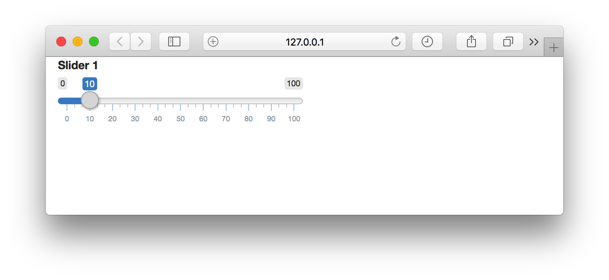

Kullanıcı tarafından girilecek değişkenimizi girdik. Şimdi de uygulama çıktılarını yerleştirelim. Önce basit bir örnek olsun. Öyle ki, uygulama, slider ile girdiğimiz değerin karesini alarak bize göstersin. Bu durum artık hesaplama yapmamızı gerektiriyor. Bu sebeple **server** kısmına geçiş yapıyoruz.

**Server** kısmında hesaplamasını yapacağımız bir değeri, sonuç olarak sistemde göstermek istiyorsak `output$deger_adi` şeklinde tanımlıyoruz. Örneğin `output$kare` gibi..

```r
library(shiny)

ui <- fluidPage(
  sliderInput(inputId = "slider1","Slider 1",
              min = 0, max = 100, value = 10))

server <- function(input, output) {
  output$kare <- reactive({ input$slider1^2 })
}

shinyApp(ui = ui, server = server)
```

Buradaki örnekte, **kare** adlı bir değişkeni tanımladık. Bu değişkenin tanımını **slider1** input değerinin karesini alacak şekilde belirledik. Şu ana kadar hazırladığınız R kodlarından farklı olarak, tanımladığınız nesne (kare), sabit bir değer olmadığı için (slider1 değeri değiştiğinde kare de güncelleneceği için) `reactive({})` ifadesi içine tanımımızı yazdık. Bu amaçla `reactive()` veya `render()` gibi fonskiyonları kullanılabiliyor.

Yukarıdaki ifadeyi çalıştırdığımızda, muhtemelen sayfanızda kare ifadesini göremeyeceksiniz. Çünkü henüz kare nesnesini arayüz (ui) içinde nasıl göstereceğimizi belirtmedik. Bunun için `textOutput()` komutunu kullanacağız. Bu komut içindeki `outputId` parametresi ile hangi değişkeni çağırmak istediğimizi (örneğimizde kare oluyor) belirteceğiz.

```r
library(shiny)

ui <- fluidPage(
  sliderInput(inputId = "slider1","Slider 1",
              min = 0, max = 100, value = 10),
  textOutput(outputId = "kare"))

server <- function(input, output) {
  output$kare <- reactive({ input$slider1^2 })
}

shinyApp(ui = ui, server = server)
```

[figure not shown]

Shiny içinde, farklı tipte çıktıları göstermek için farklı output komutları da bulunuyor. Tablo çıktısı isterseniz `tableOutput()` veya bir grafik çıktısını göstermek isterseniz `plotOutput()` kullanabilirsiniz. Bunlara da ilerideki yazılarda değineceğiz.

Bu yazıda, Shiny uygulamalarının mantığına giriş yapıp ilk uygulama denemesine başladık. Shiny, oldukça derin ve bir o kadar da esnek bir konu. Bu sebeple, tek bir yazı yeterli olmayacaktır. Gelecek yazılarda, Shiny ile ilgili daha ileri örneklere de yer vereceğiz.

**Can Holyavkin**

E-posta | [Linkedin](https://www.linkedin.com/in/can-holyavkin/) | [Twitter](https://twitter.com/CanHolyavkin)